# Analysis of cyclic peptides

Sebastian Worms

March 08, 2023

# Introduction

This is the analysis of the peptides from the drift experiment. The required datasets were created in the “peptideAnalysis.R” file. I’m going to do it on a subset of of reads for both short and large datasets at first to speed things up.

## Short peptides

Let’s have a look at the distribution of enrichment ratio:

```
$induced
   Min. 1st Qu.  Median    Mean 3rd Qu.    Max.    NA's
   0.42    0.74    0.84    0.98    1.12  116.15   38643

$repressed
   Min. 1st Qu.  Median    Mean 3rd Qu.    Max.    NA's
   0.26    0.52    0.80    0.92    1.03   87.92   94513
```

### Stop codons

Let’s look at the subset of sequences with stops codons. 104977 sequences (21.65% of the total) contains stop codons. The percentage I would expect with peptides containing 3 randomized NNK codons is 9.09% of the total, so this is much higher than expected.Looking at the sequence I have something odd in that many of the sequences don’t have a starting cysteine.

I will subtract the sequences that do not start with the correct codon (*TGC*).

This is a surprisingly large number: 235186 out of 484868 (48.51%)

So looking at only the sequences starting with TGC, we have 10.66% of stop codons, much closer to the expected 9.09%. We’ll subset only the correct ones for downstream analysis and work with the NNK3_correct data set.

### NAs

NAs here are the cases where there were no reads at the generation 1 but some after five generations. 18% of genes in the induced set and 35% in the repressed sets are such NAs. Interesting that way more reads are such NAs for the repressed set, despite it being generally less enriched.

Compared to the rest of the counts, the NAs usually have very low sequence counts even at the generation five and so probably represent rare peptides. That would explain the higher numbers of NAs in the repressed set.

### Purged NNK3 sequences

```
 enrichment_ratio
 Min.   :0.2587
 1st Qu.:0.6262
 Median :0.8095
 Mean   :0.7489
 3rd Qu.:0.8817
 Max.   :1.0000
```

Most peptides here are weakly purged. Of the 207990 peptides with an enrichment ratio that was computed, we have 137997 that are purged. But only 15845 (7.62%) have seen their frequencies reduced at least twofold.

#### Purge

No sequences seems missing or highly repressed. So no strong purge. What could have happened is that some of the ones in the induced set that are missing are actually very strongly purged there compared to the repressed set. If true, I expect them to be purged in the repressed set too.

The absent peptides are all containing relatively rare codons, with a lot of phenylalanine, tryptophane, cysteines… That could be the explanation. Looking at the data sets, all eleven peptides are “NAs” in the represed condition too, so relatively rare.

### Correlation of Enrichment ratios

I should expect the enrichment ratio for the same peptide sequence to correlate pretty well.

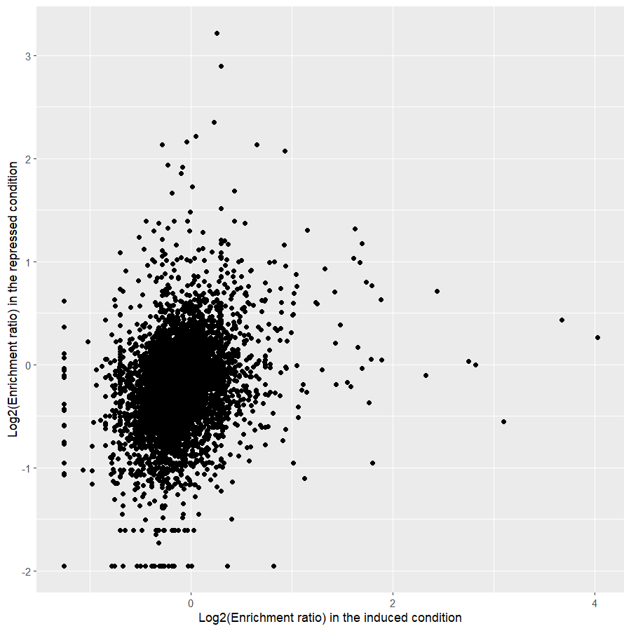

### ‘RR’ motifs

RR motifs are known to interfere with the membrane. Let look at the peptides with those motifs.

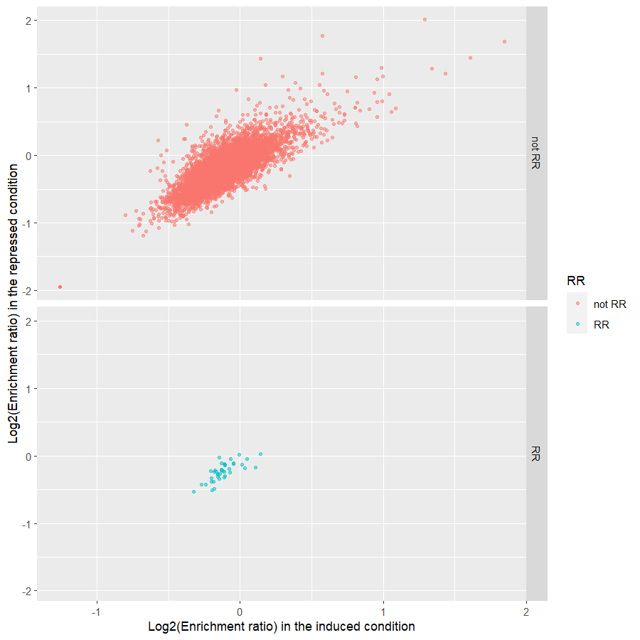

### Enrichment by charge

### Background

### Peptides with Proline

### Hydrophobicity

### Initial ration and enrichment ratios

### His-rich peptides